# 2017 Yılı Ülkelerin Mutluluk Sıralamasına İlişkin Veri Analizi Ve Regresyon Modeli İle İncelenmesi

#### 4.1.1.2. $σ^2$’nin kestirimi

İdeal olarak bu kestirimin kurulan modelin yeterliliğine bağlı olmaması tercih edilir. Bu ise yalnızca x’in en az bir değeri için y üzerinde farklı gözlemler olduğunda ya da $𝜎^2$’ye ilişkin önceliğinden elde edilmiş bilgi bulunduğunda mümkün olmalıdır. Bu yaklaşım kullanılamadığında $𝜎^2$, artık veya hata kareler toplamından elde edilir.

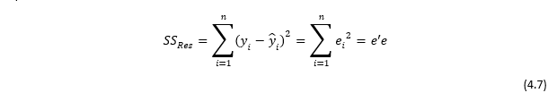

$e=y-X\hat{\beta}$ yerine konulmasıyla aşağıdaki ifade elde edilir.

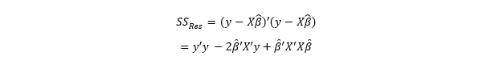

Denklem (4.7)’den son denklem aşağıdaki gibi olur.

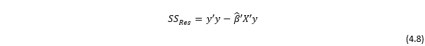

Artık kareler toplamını n-2 serbestlik derecesine sahiptir. SSRes’in beklenen değeri $E(SS_{Res})=(n-p)σ^2$ olduğu göstermektedir; dolayısı ile $σ^2$’nin yansız bir kestiricisi aşağıdaki gibidir:

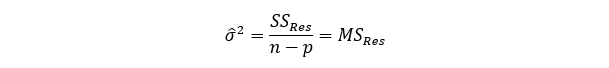

#### 4.1.1.3. Dummy Değişken

2 kategorisi olan bir değişkeni 1 ve 0 şeklinde kodladığımızda aslında tek kategoriye indirmiş oluyoruz. Örneğin erkek=0 kadın=1 olarak kodlandığında değişkeni erkek olmak ya da olmamak şeklinde yorumlayarak regresyon analizi yapılır. Burada yaptığımız bir grubu referans grubu alıp sadece diğer grubun verileri ile analiz yapıp daha sonra elde edilen regresyon katsayısını da analize giren grup üzerinden yorumlamaktır. 3 kategorisi olan değişkenlerde bunu nasıl başaracağız? Burada yapmamız gereken uygulama aynı değişken için 1. kategoride olup 2 ve 3. kategoride olmayanları, 2. kategoride olup 1. ve 3. kategoride olmayanları, 3. kategoride olup 1. ve 2. kategoride olmayanları belirtmek olacaktır. 2 kategorili durumda olduğu gibi tek değişkenle bunu başarmamız mümkün değildir. Öncelikle üç kategoriden bir tanesini referans grup olarak belirlememiz gerekmektedir. Daha sonra 2 tane yapay değişken üretmemiz gerekmektedir (k-1 sayıda yapay değişken). Bu iki yapay değişkenlerde referans grubuna ve hesaba katılmayan gruba sıfır hesaba katılan gruba da 1 rakamını gireceğiz.

### 4.1.2. Belirtme Katsayısı

Regresyonda amaçlardan birinin de bağımlı değişkendeki kaynağını araştırmak için kullanılır.

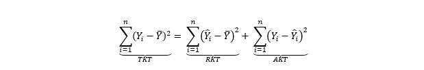

TKT:Toplam kareler Toplamı(Total Sum Of Square/SYY) RKT:Regresyon Kareler Toplamı(Regression Sum Of Squares/SSReg) AKT:Artıklar Kareler Toplamı(Residuals Sum Of Squares/SSRes) Bu sonuçlara göre bağımsız değişkenin bağımlı değişkendeki değişimin % kaçını açıkladığınının göstergesi olan belirtme katsayısı şu şekilde tanımlanır.

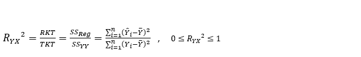

k tane bağımsız değişkenin doğrusal regresyon modelinde belirleme katsayısı bağımlı değişkenin % kaçını açıkladığını belirtir. Belirtme katsayısı iki bağımsız değişkenli doğrusal regresyon model için;

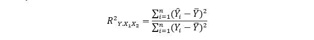

ile hesaplanır. Belirtme katsayısının yukarıdaki eşitlik ile hesaplanması fazla zaman alır. Çünkü Y ̂_i değerlerini tek tek hesaplamak gerekir. Matris işlemleri ile $\hat{Y}_i$değerinin hesaplanmasına gerek yoktur. Denklem (4.8)’te verilen aşağıdaki eşitlikler verilmişti.

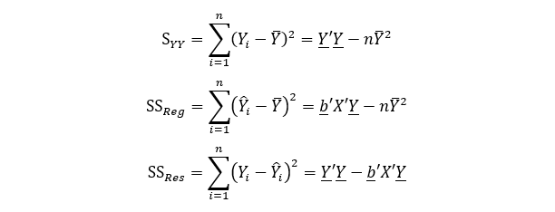

Bu durumda belirme katsayısı;

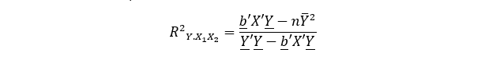

eşitliği şeklinde olur.

### 4.1.3 Kısmi F Testi

$x_1,...,x_k$ bağımsız değişkenleri arasında doğrusal ilişki olup olmadığını araştırmak için kullanılan testdir. Uygun hipotezler aşağıdaki gibidir:
$$H_0=β_1=β_2=...=β_k$$
$$H_A=En~az~biri~ sıfırdan~ faklıdır.$$

$H_0$ hipotezinin reddedilmesi için $x_1,...,x_k$ bağımsız değişkenlerinden en az birinin modele anlamlı katkı sağlaması gerekmektedir. Bu test basit doğrusal regresyonun genelleştirilmesidir.

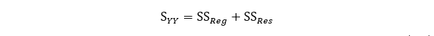

$H_0$ hipotezi doğru iken;

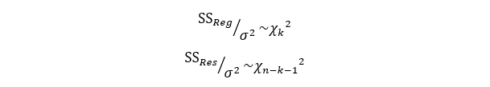

olacak şekilde dağılır. Ve F istatistiğinin tanımından;

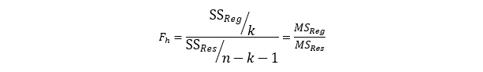

oranının Fk,n-k-1 dağıldığı görülür. $H_0$ hipotezini test etmek için $F_h$ test değeri hesaplanır ve $F_h> F_{k,n-k-1}$ geçerli ise $H_0$ reddedilir.

### 4.1.5. Kısmi Korelasyon Katsayısı

Y ve $X_1$§ değişkenleri arasındaki korelasyon katsayısı hesaplanırken herhangi bir başka değişkenin etkisinin Y ve $X_1$ değişkenlerini üzerindeki etkisi arındırıldıktan sonraki iki değişkenin arasındaki korelasyon katsayısıdır.

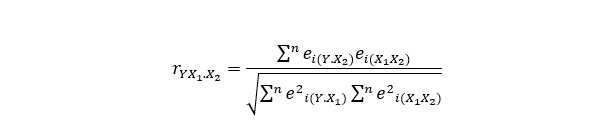

### 4.1.6. Artıkların İncelenmesi

**Artıkların(Hataların) Tanımı:**

Artıklar $e_i=y_i-y ̂_i$ olarak tanımlanır. $y_i$ gözlem $y ̂_i$ ise regresyon sonucu elde edilen değerdir. Artıkların analizi farklı türdeki model yetersizliklerini ortaya çıkarılmasında etkilidir. Artık çizimleri regresyon modelinin verilere ne kadar uyumlu olduğunu gösterir. Artıklar sıfır ortalamaya sahip olup yaklaşık ortalama varyansları MSRes değeridir.Standartlaştırılmış artık: Bir artığın MSRes değeri ile kestirildiğinden artıklar için standartlaştıırlmış artık denir.

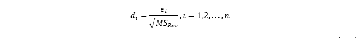

Standartlaştırılmış artık $(|d_i|>3)$ potansiyel bir aykırı değer işaretidir.

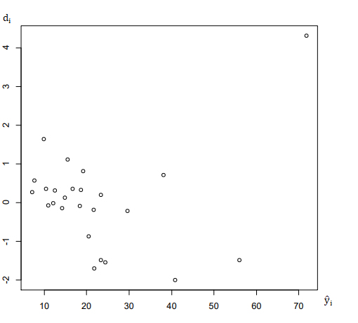

**1. Sabit Varyanslılık**

Hata terimi varyansı, bağımsız değişkendeki değişimlere bağlı olarak değişiyorsa değişen varyans, değişmiyorsa sabit varyans söz konusudur. Değişen Varyans $Var(ε_i)=E(ε^2_i)=σ^2_{ε_i}, ~ε_i$ hata teriminin varyasının farklı olduğunu gösterir.

**Değişen varyanslığın nedenleri şu şekilde sıralanabilir;**

- Değişkenlerden birisinin çarpık olması.
- $y ̅$ ile $σ^2_y$ ilişkili olması.
- Bir bağımsız değişkenin model dışında kalması.

**Değişen varyansılılığın sonuçları;**

- Minimum varyanslılık ortadan kalkar.

**Değişen varyansılılığın ortya çıkartılması;**

- Grafik ile ortaya çıkartılır.

**2. Hataların Normal Normal Dağılması**

Q-Q çizimleri ile bulunur. Kesikli veri veya farklı dağılımlı olması yüzünde ortaya çıkar. Gidermek için dağılıma uygun regresyon modeli veya dönüşüm yapılmalıdır.

### 4.1.7. Otokorelasyon (İlişkili Hatalar)

Çoklu doğrusal regresyon analizinde otokorelasyon, hata teriminin birbirini izleyen değerleri arasındaki ilişkiyi tanımlar. Bu durum, genel doğrusal regresyon modelinin önemli bir varsayımından sapmadır. Genel doğrusal regresyon modeli varsayım gereği olarak, hata terimleri arasında bir ilişki yoktur. Gözlemlenen değerler arasındaki benzerliğin, zamansal gecikmenin bir fonksiyonu olarak ifadesidir. Otokorelasyon analizi tekrar eden örüntülerin tanınması, bir sinyalin kayıp temel frekansının tespit edilmesi gibi amaçlar için kullanılan bir matematiksel araçtır. Sinyal işlemede fonksiyonların ya da dizilerin analizi için sıkça kullanılır.

**Otokorelasyonun nedenleri şu şekilde sıralanabilir;**

- Bazı açıklayıcı değişkenlerin modele alınmaması.
- Modelin matematiksel biçiminin yanlış seçilmesi.
- Açıklanan değişkende ölçme hatası olması.
- Verilerin işlenmesi.
- Hata teriminin yanlış belirlenmesi..

**Otokorelasyon sonucunda ise;**

- Parametre tahminleri sapmasız olmakla birlikte etkin değildir.
- Hata teriminin varyansı, olduğundan küçük tahmin edilmektedir.
- E.K.K. tahminlerine göre yapılan öngörüler etkin değildir.

**Otokorelasyonun ortaya çıkartılması;**

- Grafik ile ortaya çıkar.
- eilerin dağılımı rastgele değilse.
- Durbin-Watson Test istatistiği ile.

Ardaşık hata terimlerini bağımsız olamdığında yapılacak tahminler yanlış olacağı için hata terimlerinin bağımsızlığının test etmek gerekir. En çok bilinen testlerden biri Durbin-Watson testidir.

**Durbin-Watson Testi**

Bu test sadece birinci derecedeki otokorelasyonun bulunup bulunmadığını sınamaktadır.
$$H_0:P=0(Ototkorelasyan yoktur.)$$

$$H_A:P≠0(Otokorelasyon vardır.)$$

seçilen bir anlamlılık düzeyi ile gözlem sayısı ve açıklayıcı değişken sayısına göre, Durbin-Watson tablosundan, d istatistiğinin alt $(d_L)$ ve üst $(d_U)$ sınırları bulunur.Sonra Kritik oran d istatistiği hesaplanır.

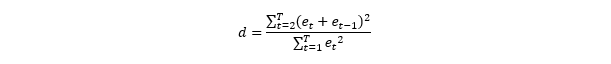

### 4.1.7. Çoklu Bağıntı

Regresyon analizinde parametre kestirimlerinin yansızlığı ve duyarlılığı, ifade edilen bu varsayımların gerçekleşmesine bağlıdır. Ancak bazı olayların analizinde bu varsayımlardan sapmalar görülmektedir. Bunlardan biri olan bağımsız değişkenlerin birbirleriyle ilişkili olması durumu çoklu bağıntı olarak ifade edilmektedir.

#### 4.1.7.1. Varyans Şişirme Oranı

Çoklu bağıntının belirlenmesinde en kolay ve en sık kullanılan tekniklerden birisidir. Çünkü istatistik paket programlarının çoğunda kısmi korelasyon katsayıları kolayca belirlenebilir. Bir ya da daha fazla kısmi korelasyon katsayısının 0.8 ya da 0.9 değerinden büyük olması, çoklu bağıntı sorununun olabileceğini gösterecektir fakat iki bağımsız değişken arasında yüksek bir ilişki olmaması çoklu bağıntı olmadığının ispatı değildir. Çoklu belirleme katsayısından hareketle elde edilen varyans büyütme faktörü de çoklu bağıntının göstergelerinden biridir. j’inci bağımsız değişkenin öteki k-1 bağımsız değişkenlerce belirleme katsayısı $R^2_j$ 1’e yakınsa j. değişkenin güçlü bir çoklu bağıntı içinde olduğu söylenebilir. Korelasyon matrisi tersinin köşegen elemanları Cjj ile gösterilmek üzere standartlaştırılmış ($X_s$) matrisi yardımıyla $C=( X_sX_s′ )^{-1}$ için

$$R_j^2=1-C_{jj}^{-1} ~~~ ,~~~ j=1,...,k$$

yardımıyla kolayca bulunabilir. j’inci bir bağımsız değişken $X_j$, diğer değişkenlerle ilişkili değilse $R^2_J$ küçüktür ve $C_{jj}$ 1’e yakındır. Eğer Xj geriye kalan bağımsız değişkenlerle doğrusala yakın bir ilişki içindeyse $R^2 ≅1$’dir ve $C_jj$ de küçüktür. Çoklu doğrusal regresyonda j’inci regresyon katsayısının varyansı $C_{jj}σ^2$ olduğuna göre, bağımsız değişkenler arasındaki doğrusal bağımlılık yüzünden Cjj, b ̂_j ’nin varyansını artıran bir faktördür. Marquardt (1970) tarafından önerilen ve çoklu regresyon analizinde kullanılan varyans büyütme faktörü

$$VIF_j=C_j=(1-R^2_j)^-1$$

ile belirlenir. Bir yada daha fazla varyans büyütme faktörü VIF ≥ 5 ya da VIF ≥ 10 ise çoklu bağıntı sorunu olduğu ifade edilir.

# 5. UYGULAMALAR

Yapılacak analizler ülkelerin 2017 yılı mutluluk sıralamasına ilişkin verilerin analizleridir. Bu analizler Spss, R(ggplot2, easyggplot2, biotools ve Ggally kütüphaneleri kullanılmıştır.) ve Python( pandas, numpy, matplotlib, seaborn, ve scipy kütüphaneleri kullanılmıştır.) ile yapılmıştır. Veri seti incelenmeye başlamadan önce uygulama boyunca kullanılacak olan verilerin isimlerinin Türkçe karşılığı kullanılmıştır. Veri setinde 126 tane gözlem bulunmaktadır. Kullanılan veri https://www.kaggle.com/adwaywadekar/social-progress-and-happiness adresi üzerinden alınmıştır.

**Veri setinde 126 ülkeye ait 26 adet özellikten kullanılanlar;**

[output not shown]

Personal Freedom(Kişisel Özgürlük) değişkeni analizlerde kullanılmak üzere kategorize edilmiştir.

**Bu kategoriler;**

• 55’ten küçük olanlara özgür değil

• 55 ile 70 arasında olanlara yarı özgür

• 70’ten büyük olanlar özgür denilmiştir.

Değişkenlerin dummy değişken gösterimi

[output not shown]

Ödevde yapılan tüm testeler %95 güven düzeyi ile ölçülmüştür. Tüm p değerleri için 0.05 ile karşılaştırılıp karar verilmiştir.

Dünya Mutluluk Raporu, 126 ülkeyi vatandaşlarının kendilerini ne kadar mutlu algıladıklarına göre sıralayan küresel mutluluk durumunun önemli bir araştırmasıdır. 2017 yılının Dünya Mutluluk Raporu mutluluk ve topluma odaklanıyor: bu değişiklikleri yönlendiren teknolojilere, sosyal normlara, çatışmalara ve hükümet politikalarına odaklanarak mutluluğun 2017 yılında nasıl geliştiğini gösterir. Dünya mutluluk Raporu, insanları neyin mutlu ettiğini daha iyi anlamak isteyen politika yapıcılar için vazgeçilmez bir araç olduğu kanıtlanmıştır. Zaman ve tekrar refahın nedenlerinin iyi sosyal destek ağları, sosyal güven, dürüst hükümetler, güvenli ortamlar ve sağlıklı yaşamlar olduğu görülür. Mutlu bir sosyal çevre, insanların aidiyet duygusu hissettikleri, birbirlerine ve ortak Kurumlarına güvendikleri bir ortamdır. Ayrıca daha fazla esneklik vardır, çünkü paylaşılan güven zorlukların yükünü azaltır ve böylece refahın eşitsizliğini azaltır. Mutluluk eşitsizliği ortalama yaşam değerlendirmelerini önemli ölçüde azaltır. Bu, insanların yaşam kalitesinde aşırı eşitsizlik olmadan toplumlarda yaşamaktan daha mutlu oldukları anlamına gelir. Bu diploma çalışmasında 2017 yılına ait dünya mutluluk raporu veri setine veri analizi ve doğrusal regresyon modellerini kullanarak hangi değişkenlerin daha iyi sonuç verdiğinin incelemesine yer verilmiştir.

**Destopya nedir?**

Destopya, dünyanın en az mutlu insanına sahip hayali bir ülkedir. Destopya kurmanın amacı, altı temel değişkenin her biri açısından tüm ülkelerin olumlu olarak karşılaştırılabileceği (hiçbir ülke Destopya’dan daha kötü performans göstermeyecek) bir ölçüt oluşturmaktır, böylece her alt çubuğun pozitif (veya sıfır, sıfırın altı durumda) olmasına izin vermek. Dünyanın en düşük gelirine, en düşük yaşam beklentisine, en düşük cömertliğe, en çok yolsuzluğa, en az özgürlüğe ve en az sosyal desteğe sahip bir ülkede yaşam çok tatsız olacağı için, Ütopya’nın aksine “Destopya” olarak adlandırılmaktadır.

```r
as_tibble(happy)
```

| Country | Happiness_score | Dystopia | Freedom_to_make_life_choices | Generosity | Social_support | Personal_Rights | Personal_Freedom |
| --- | --- | --- | --- | --- | --- | --- | --- |
| Afghanistan | 3.794 | 2.151 | 0.3255764 | 0.5585696 | 0.7628892 | 6.115554 | ozgur_degil |
| Albania | 4.644 | 1.490 | 0.6172520 | 0.4483302 | 0.8966605 | 7.780103 | ozgur_degil |
| Algeria | 5.872 | 2.568 | 0.4827007 | 0.2626785 | 1.0705139 | 6.017475 | yari_ozgur |
| Angola | 3.795 | 1.614 | 0.0000000 | 0.3130495 | 1.0507140 | 5.317894 | ozgur_degil |
| Argentina | 6.599 | 2.614 | 0.7035624 | 0.3301515 | 1.2000000 | 8.216447 | yari_ozgur |
| Armenia | 4.376 | 1.521 | 0.4449719 | 0.2880972 | 1.0034939 | 6.562012 | ozgur_degil |
| Australia | 7.284 | 2.065 | 0.7758866 | 0.6913754 | 1.2288206 | 9.664885 | ozgur |
| Austria | 7.006 | 2.139 | 0.7536577 | 0.5621388 | 1.2083046 | 9.691749 | ozgur |
| Azerbaijan | 5.234 | 1.762 | 0.6308724 | 0.2121320 | 1.0733126 | 4.289522 | ozgur_degil |
| Bangladesh | 4.608 | 1.979 | 0.6913754 | 0.4147288 | 0.8573214 | 6.126173 | ozgur_degil |

[output cut: 116 more lines]

Verilerin tam hali

```r
glimpse(happy)
```

```
## Rows: 126
## Columns: 8
## $ Country                      <chr> "Afghanistan", "Albania", "Algeria", "...
## $ Happiness_score              <dbl> 3.794, 4.644, 5.872, 3.795, 6.599, 4.3...
## $ Dystopia                     <dbl> 2.151, 1.490, 2.568, 1.614, 2.614, 1.5...
## $ Freedom_to_make_life_choices <dbl> 0.3255764, 0.6172520, 0.4827007, 0.000...
## $ Generosity                   <dbl> 0.5585696, 0.4483302, 0.2626785, 0.313...
## $ Social_support               <dbl> 0.7628892, 0.8966605, 1.0705139, 1.050...
## $ Personal_Rights              <dbl> 6.115554, 7.780103, 6.017475, 5.317894...
## $ Personal_Freedom             <chr> "ozgur_degil", "ozgur_degil", "yari_oz...
```

## 5.1. Büyük Veri Kümelerinde Veri Analizi

Yapılan birçok araştırmada, toplanan verilerde eksikler ile karşılaşılır. Bu eksik değerler(kayıp gözlemler) istatistiksel analizlerde araştırmacıların karşılaştığı önemli sorunlardan birisidir. Veri seti incelendiğinde kayıp gözlem bulunmadığı için ek işlem yapılmasına gerek yoktur.Bu yüzden veri seti hakkında bilgi sahibi olmak için belirleyici istatistikler ve grafikler kullanılacaktır.

### 5.1.1.Belirleyici istatistikler

Veriler düzenlendikten sonra, veri kümesindeki değişkenlerin özellikleri değişkenin özetleyici ölçülerinin incelenmesi ile ortaya çıkar

```r
summary(happy)
```

```
##    Country          Happiness_score    Dystopia
##  Length:126         Min.   :3.349   Min.   :0.378
##  Class :character   1st Qu.:4.546   1st Qu.:1.615
##  Mode  :character   Median :5.302   Median :1.864
##                     Mean   :5.404   Mean   :1.891
##                     3rd Qu.:6.103   3rd Qu.:2.207
##                     Max.   :7.537   Max.   :3.117
##  Freedom_to_make_life_choices   Generosity     Social_support   Personal_Rights
##  Min.   :0.0000               Min.   :0.0000   Min.   :0.6573   Min.   :2.304
##  1st Qu.:0.5710               1st Qu.:0.3850   1st Qu.:1.0209   1st Qu.:6.619
##  Median :0.6622               Median :0.4712   Median :1.1203   Median :7.948
##  Mean   :0.6350               Mean   :0.4672   Mean   :1.0893   Mean   :7.630
##  3rd Qu.:0.7124               3rd Qu.:0.5608   3rd Qu.:1.1951   3rd Qu.:8.906
##  Max.   :0.8112               Max.   :0.9154   Max.   :1.2693   Max.   :9.894
##  Personal_Freedom
##  Length:126
##  Class :character
##  Mode  :character
##
##
##
```

## 5.1.2. İlişki Ölçüleri

Pearson Korelasyon Katsayısı Veri setindeki değişkenlerin aralarındaki ilişkinin incelenmesi çok önemlidir.Bu sayede aralarında yüksek ilişki olan değişkenler regresyon modeline alınmayacak. Eğer alınsaydı çoklu bağıntı problemi meydana gelecekti. Analizde pearson korelasyon katsayısı ile değişkenlerin ilişkileri test edilecek ve 0,75’ten büyük değerler yüksek ilişkili kabul edildiği için çalışmaya alınmamıştır.

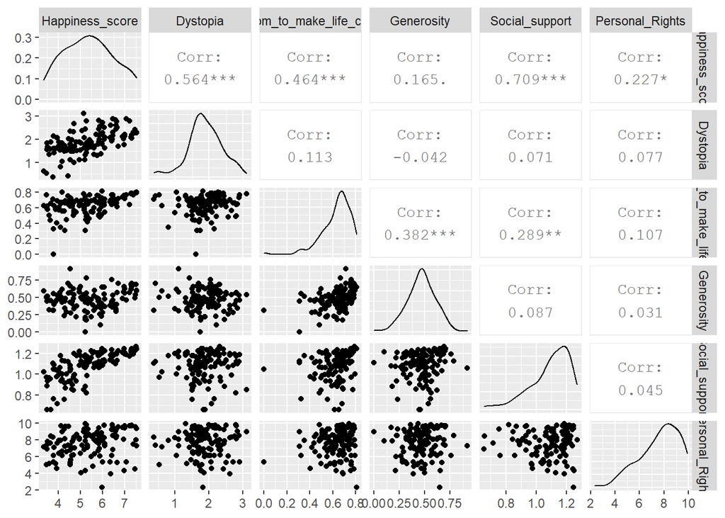

Değişkenleri genel olarak inceleyince tüm değişkenler arasında çok yüksek korelasyon olmadığı gözlemlenmiştir. Ancak; mutluluk skoru ve sosyal destek arasında pozitif korelasyonun var olduğu görülmektedir. Bu elde edilen ikili ilişkiler regresyon analizi için de daha sonra dikkate alınıp regresyon modeli oluşturulacaktır.

## 5.1.3. Grafikler

### 5.1.3.1. Mutluluk Skoru

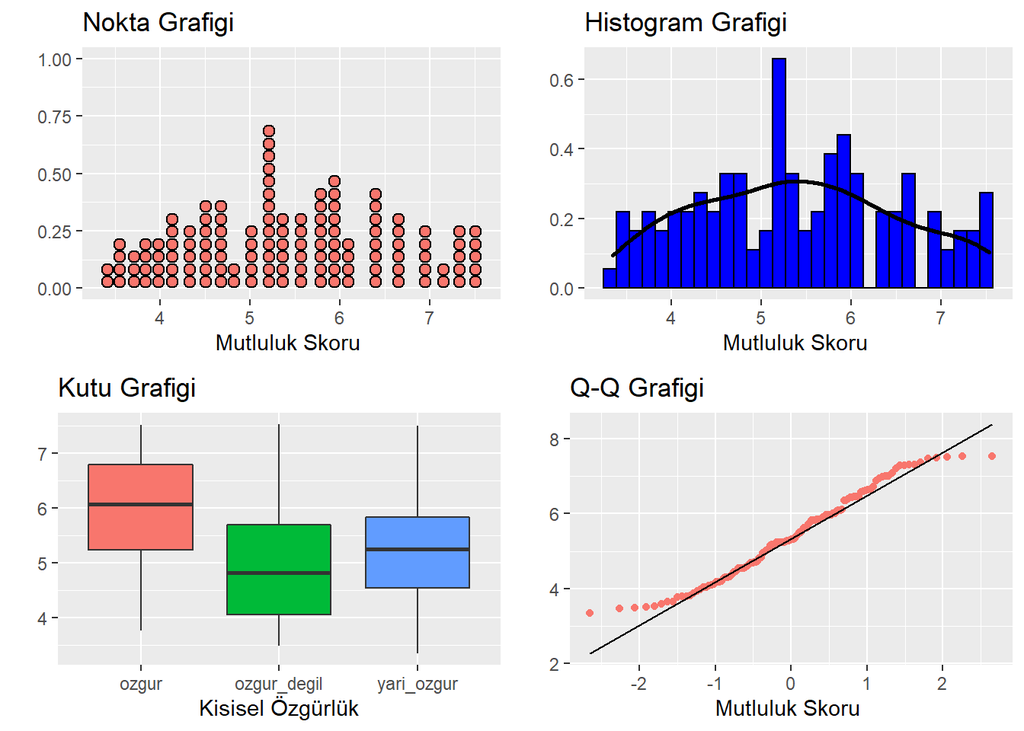

Histogram ve nokta grafiğine bakıldığı zaman değişkende çarpıklığın az olduğu görülmektedir. Q-Q grafiğinde çizilen doğrusal çizginin üzerindeki noktalar, değişkenin teorik olarak normal dağılıma yakınsadığını gösterir. Mutluluk skoru değişkeninin nokta ve histogram grafiğine bakıldığında çarpıklık olmadığı gözükür. Uç değerlerin olmadığı gözükür. Kutu grafiğine bakıldığı zaman kişisel özgürlük bakımından kendini özgür hisseden ülkelerin mutluluk skorunun modu daha yüksek iken özgür hissetmeyen ülkelerin mutluluk skorundan daha düşük olur. Histogram ve nokta grafiğindeki uç değerlerin gözükmemesi ve parçalanmış kutu grafiğinde gözükmemesi uç değerlerin olmadığını gösterir.

### 5.1.3.2. Destopya

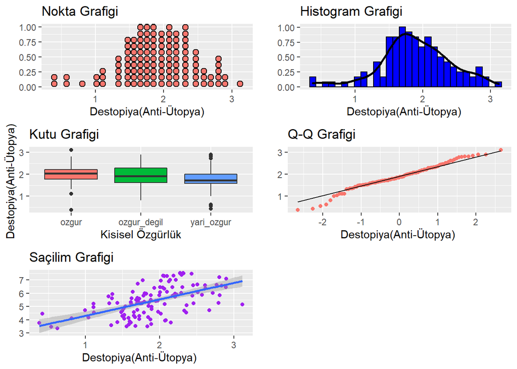

Destopya değişkeninin nokta ve histogram grafiğine bakıldığında çarpıklıktan tam söz edilemez. Uç değerlerinin olduğu gözükür. Kutu grafiğine bakıldığı zaman kişisel özgürlük bakımından kendini özgür hisseden ülkelerin destopya modu ile diğer ülkelerin modu birbirine yakındır. Parçalanmış kutu grafiğinde uç değerlerin histogram ve nokta grafiğinde gözükenden daha fazla olduğu ortaya çıkar. Q-Q grafiğinde değişkenin normallik varsayımını sağlamadığı gözükür. Saçılım grafiği ise, mutluluk puanı ile arasındaki ilişkinin doğrusal ilişkiye yakın olduğu gözükür. Doğrudaki değerlerin topladığı yerdeki gölgelerin küçüklüğü standart sapmanın az olduğunu gösterir.

### 5.1.3.3. Seçim Yapma Özgürlüğü

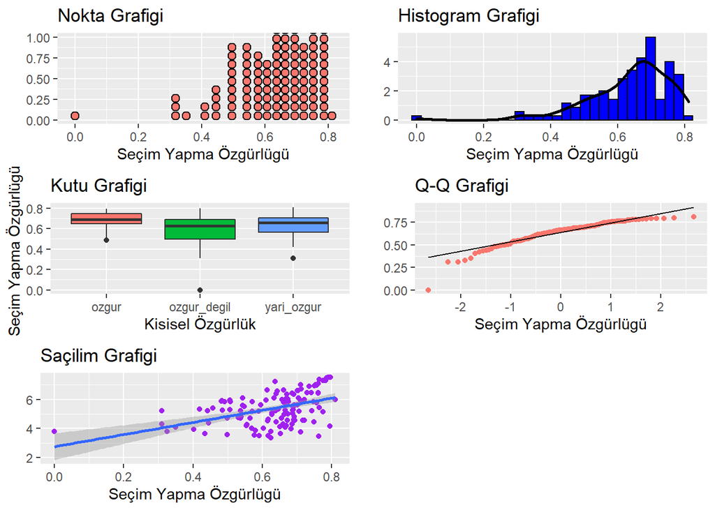

### 5.1.3.4. Cömertlik

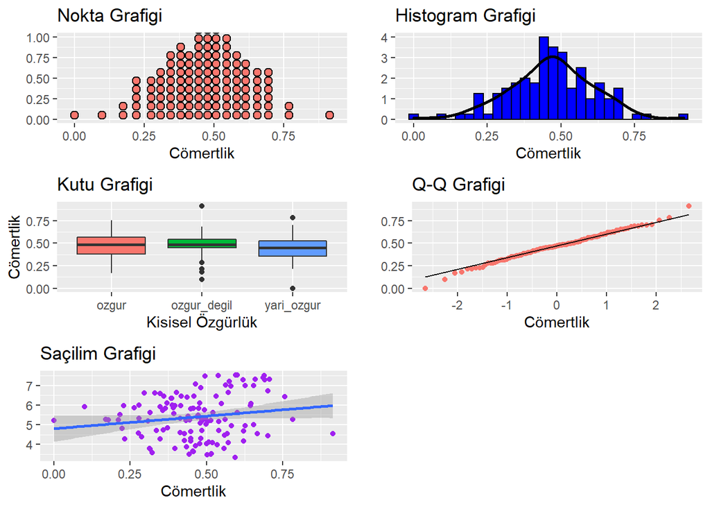

### 5.1.3.5. Sosyal Destek

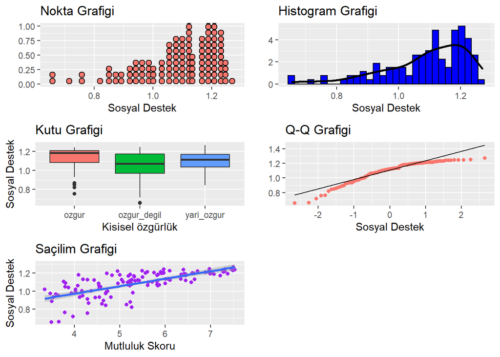

### 5.1.3.6. Kişisel Haklar

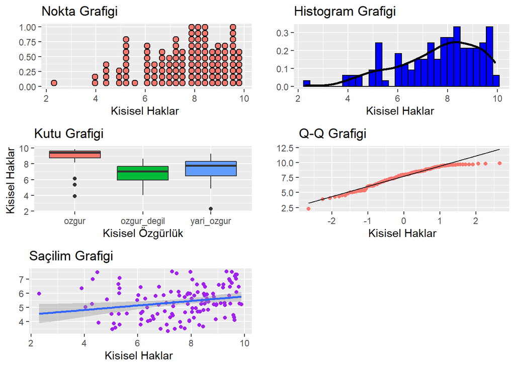

Kişisel haklar değişkeninin nokta ve histogram grafiğine bakıldığında sola çarpık olduğu ve uç değerlerin olduğu gözükür. Kutu grafiğine bakıldığı zaman kişisel özgürlük bakımından kendini özgür hisseden ülkelerin kişisel haklarının modu daha yüksek iken özgür hissetmeyen ülkelerin kişisel hakları daha düşük olur. Yani kendini özgür hisseden ülkelerde kişisel hakları daha fazladır. Histogram ve nokta grafiğindeki uç değerlerin daha fazla olduğu parçalanmış kutu grafiğinde gözükür. Q-Q çizimlerinde ise normallik varsayımını sağlamadığı ve değişenin çarpıklığının az olduğu gözükür. Saçılım grafiği ise, mutluluk puanı ile arasındaki ilişkinin doğrusal ilişkiye yakın olmadığı gözükür. Doğrudaki değerlerin topladığı yerdeki gölgelerin gölgelerin büyüklüğü standart sapmanın yüksek olduğunu gösterir.

### 5.1.3.7. Kişisel Özgürlük

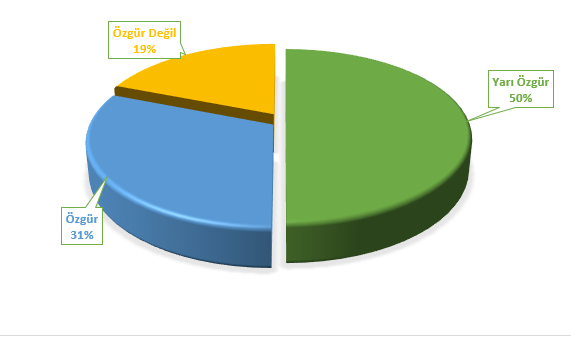

## 5.2.Normal Dağılım

### 5.2.1. Normallik İncelemesi

```
Veri setindeki değişkenlerin normallik incelemesini yapmak için Shapiro-Wilk test istatistiği kullanılmıştır. Gözlem sayısı 5000’den küçük olan veri setleri için uygundur. Teste ait hipotezler aşağıdaki şekildedir.
```

$H_0$:Değişkenlerin dağılımı normal dağılımdan gelmektedir.

$H_A$:Değişkenler dağılımı normal dağılımdan gelmemektedir.

```r
shapiro.test(Happiness_score)
```

```
##
##  Shapiro-Wilk normality test
##
## data:  Happiness_score
## W = 0.97169, p-value = 0.009546
```

```r
shapiro.test(Dystopia)
```

```
##
##  Shapiro-Wilk normality test
##
## data:  Dystopia
## W = 0.97874, p-value = 0.04453
```

```r
shapiro.test(Freedom_to_make_life_choices)
```

```
##
##  Shapiro-Wilk normality test
##
## data:  Freedom_to_make_life_choices
## W = 0.89138, p-value = 4.062e-08
```

```r
shapiro.test(Generosity)
```

```
##
##  Shapiro-Wilk normality test
##
## data:  Generosity
## W = 0.9931, p-value = 0.7959
```

```r
shapiro.test(Social_support)
```

```
##
##  Shapiro-Wilk normality test
##
## data:  Social_support
## W = 0.89895, p-value = 9.857e-08
```

```r
shapiro.test(Personal_Rights)
```

```
##
##  Shapiro-Wilk normality test
##
## data:  Personal_Rights
## W = 0.94323, p-value = 4.675e-05
```

```r
shapiro.test(ln_happy$Happiness_score)
```

```
##
##  Shapiro-Wilk normality test
##
## data:  ln_happy$Happiness_score
## W = 0.97085, p-value = 0.00798
```

```r
shapiro.test(ln_happy$Dystopia)
```

```
##
##  Shapiro-Wilk normality test
##
## data:  ln_happy$Dystopia
## W = 0.83786, p-value = 1.873e-10
```

```r
shapiro.test(ln_happy$Freedom_to_make_life_choices)
```

```
##
##  Shapiro-Wilk normality test
##
## data:  ln_happy$Freedom_to_make_life_choices
## W = 0.83585, p-value = 1.568e-10
```

```r
shapiro.test(ln_happy$Generosity)
```

```
##
##  Shapiro-Wilk normality test
##
## data:  ln_happy$Generosity
## W = 0.98006, p-value = 0.05974
```

```r
shapiro.test(ln_happy$Social_support)
```

```
##
##  Shapiro-Wilk normality test
##
## data:  ln_happy$Social_support
## W = 0.87827, p-value = 9.532e-09
```

```r
shapiro.test(ln_happy$Personal_Rights)
```

```
##
##  Shapiro-Wilk normality test
##
## data:  ln_happy$Personal_Rights
## W = 0.8744, p-value = 6.333e-09
```

**Merkezi Limit Teoremine göre örneklem sayısı 126 olduğu için normal dağıldığı varsayılmıştır.**

### 5.2.2. Çarpıklık Ve Basıklık

[output not shown]

## 5.3.Varyans Analizi

### 5.3.1. Tek Yönlü Varyans Analizi(One-Way Anova)

Çalışmanın bu kısmında ülkelerin özgürlük seviyelerinin ortalama mutluluk puanlarının üzerinde etkili olup olmadığını araştıracağız.

[output not shown]

```r
kruskal.test(Happiness_score ~ Personal_Freedom, data = happy)
```

```
##
##  Kruskal-Wallis rank sum test
##
## data:  Happiness_score by Personal_Freedom
## Kruskal-Wallis chi-squared = 15.49, df = 2, p-value = 0.0004328
```

$H_0$: Özgürlük seviyelerinin ortalama mutluluk puanı eşittir.

$H_A$: Özgürlük seviyelerinin ortalama mutluluk puanı ile arasında farklılık vardır.

Sig.=0,00 değeri 0,05’ten küçük olduğu için $H_0$ reddedilir. Yani %95 güven ile özgürlük seviyeleri arası ortalama mutluluk puanı ile arasında farklılık vardır.

Ülkelerin özgürlük seviyelerinin mutluluk puanı üzerindeki etkisinin olup olmadığını araştırılmıştır.

```r
leveneTest(Happiness_score ~ Personal_Freedom, data = happy)
```

|  | Df | F value | Pr(>F) |
| --- | --- | --- | --- |
| group | 2 | 0.960539 | 0.3855382 |
|  | 123 | NA | NA |

$H_0$: Grupların (Ülkelerin özgürlük düzeylerinin) varyansları homojendir.

$H_A$: Grupların (Ülkelerin özgürlük düzeylerinin) varyansları homojen değildir.

```r
res.aov <- aov(Happiness_score ~ Personal_Freedom, data = happy)
summary(res.aov)
```

```
##                   Df Sum Sq Mean Sq F value   Pr(>F)
## Personal_Freedom   2  19.95   9.973   8.921 0.000241 ***
## Residuals        123 137.51   1.118
## ---
## Signif. codes:  0 '***' 0.001 '**' 0.01 '*' 0.05 '.' 0.1 ' ' 1
```

$H_0$: Grupların ortalamaları arasında anlamlı farklılık yoktur.

$H_A$: Grupların ortalamaları arasında anlamlı farklılık vardır.

Anova tablosu p istatistiği 0,00<0,05 olduğu için $H_0$ hipotezi reddedilir. Yani %95 güven ile ortalama mutluluk puanı ülkelerin özgürlük düzeyi ile istatistiksel olarak anlamları bir farklılık gösterir.

```r
TukeyHSD(res.aov)
```

```
##   Tukey multiple comparisons of means
##     95% family-wise confidence level
##
## Fit: aov(formula = Happiness_score ~ Personal_Freedom, data = happy)
##
## $Personal_Freedom
##                              diff        lwr        upr     p adj
## ozgur_degil-ozgur      -0.9228632 -1.5026369 -0.3430896 0.0007168
## yari_ozgur-ozgur       -0.8061116 -1.3397110 -0.2725123 0.0014025
## yari_ozgur-ozgur_degil  0.1167516 -0.4293013  0.6628045 0.8679544
```

Grupların varyansları eşit olduğu için Tukey testi istatistikleri yazılmıştır.

$H_0$: İki Grup ortalaması arasında anlamlı bir farklılık yoktur.0

$H_A$: İki Grup ortalaması arasında anlamlı bir farklılık vardır.

Özgür ile yarı özgür gruplarının p değeri 0,05’ten küçük olduğu için $H_0$ reddedilir. Yani %95 güven ile özgür ile yarı özgür gruplarının ortalaması arasında fark vardır. Özgür ile özgür değil gruplarının p değeri 0,05’ten küçük olduğu için gruplarının ortalaması arasında fark vardır. Yarı özgür ile özgür değil gruplarının p değeri 0,05’ten büyük olduğu için gruplarının ortalaması arasında fark yoktur.

## 5.4. Regresyon

### 5.4.1. Çoklu Doğrusal Regresyon

#### 5.4.1.1. En Küçük kareler Kestiricisi

```r
happy.model=lm(Happiness_score~., data=ln_happy)
happy.model
```

```
##
## Call:
## lm(formula = Happiness_score ~ ., data = ln_happy)
##
## Coefficients:
##                  (Intercept)                      Dystopia
##                     -0.38909                       0.29974
## Freedom_to_make_life_choices                    Generosity
##                      0.55771                       0.03467
##               Social_support               Personal_Rights
##                      1.96525                       0.08705
##  Personal_Freedomozgur_degil    Personal_Freedomyari_ozgur
##                     -0.03031                      -0.04453
```

#### 5.4.1.2. Belirtme Katsayısı Ve Kısmi F Testi

```r
summary(happy.model)
```

```
##
## Call:
## lm(formula = Happiness_score ~ ., data = ln_happy)
##
## Residuals:
##      Min       1Q   Median       3Q      Max
## -0.23893 -0.05410  0.01408  0.05214  0.23183
##
## Coefficients:
##                              Estimate Std. Error t value Pr(>|t|)
## (Intercept)                  -0.38909    0.14041  -2.771  0.00649 **
## Dystopia                      0.29974    0.02426  12.357  < 2e-16 ***
## Freedom_to_make_life_choices  0.55771    0.11358   4.910 2.95e-06 ***
## Generosity                    0.03467    0.08745   0.396  0.69247
## Social_support                1.96525    0.12931  15.198  < 2e-16 ***
## Personal_Rights               0.08705    0.03811   2.284  0.02413 *
## Personal_Freedomozgur_degil  -0.03031    0.02558  -1.185  0.23856
## Personal_Freedomyari_ozgur   -0.04453    0.02150  -2.071  0.04053 *
## ---
## Signif. codes:  0 '***' 0.001 '**' 0.01 '*' 0.05 '.' 0.1 ' ' 1
##
## Residual standard error: 0.0904 on 118 degrees of freedom
## Multiple R-squared:  0.8294, Adjusted R-squared:  0.8193
## F-statistic: 81.95 on 7 and 118 DF,  p-value: < 2.2e-16
```

**Belirtme Katsayısı**

**Kısmi F Testi**

$H_0$:Bağımsız değişkenlerin kurulan modele anlamlı bir katkısı yoktur. $H_A$: Bağımsız değişkenlerin kurulan modele anlamlı bir katkısı vardır. Anova tablosundaki F istatistiğinin p değeri 0,05’ten küçük olduğu için $H_0$ hipotezi reddedilir. Yani %95 güven ile kurulan model anlamlıdır.

#### 5.4.1.3. Artık İncelemesi

**1.Sabit varyanslılık**

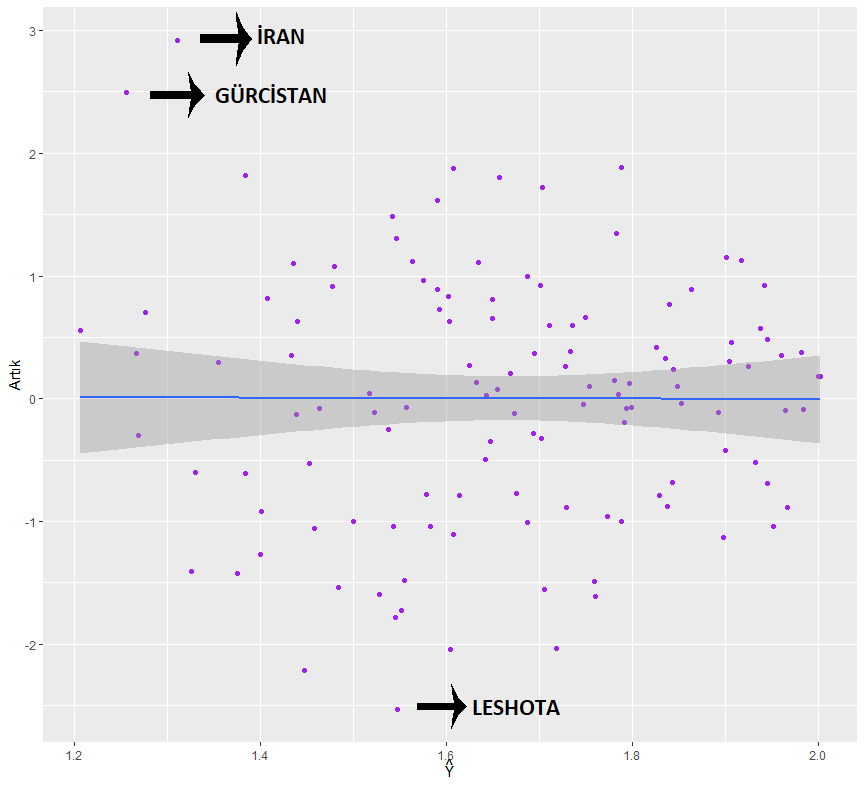

Grafikte artıkların doğrusal olmayan herhangi bir kalıpta olmadığını gösterir. Artıkların saçılım grafiği incelendiğinde çizilen doğrunun düz çizgiye yakın olduğu görülür ve doğrudaki gölgeler sapmaların yüksek olduğunun gösterir yani artıkların standart sapması yüksektir. Değişen varyanslılık yoktur.

**2. Hataların Normal Dağılması**

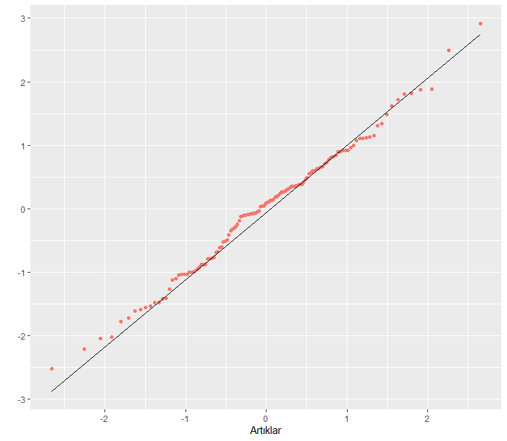

Q-Q çizmlerinde ise artıkların normal dağılımı yakın görülmektedir. Hatalar hafif sola çarpıktır.

#### 5.4.1.4.Otokorelasyon

```
##
##  Durbin-Watson test
##
## data:  happy.model
## DW = 1.7992, p-value = 0.1275
## alternative hypothesis: true autocorrelation is greater than 0
```

$$H_0:P=0 (Ototkorelasyan yoktur.)$$

$$H_A:P≠0 (Otokorelasyon vardır.)$$

#### 5.4.1.5. Varyans Şişirme Oranı

```r
print(vif(happy.model))
```

```
##                                  GVIF Df GVIF^(1/(2*Df))
## Dystopia                     1.041247  1        1.020415
## Freedom_to_make_life_choices 1.352514  1        1.162976
## Generosity                   1.190815  1        1.091245
## Social_support               1.116829  1        1.056801
## Personal_Rights              1.346212  1        1.160264
## Personal_Freedom             1.585951  2        1.122206
```

$VIF_j$ değerlerini karşılaştırmak için 10 değeri baz alınmıştır. Değişkenlerin VIF değerleri 10’dan küçük olduğu için değişkenler arasında çoklu bağıntının olduğu değişken yoktur.

# Kaynakça

• https://tr.wikipedia.org/wiki/Normal_dağılım

• https://tr.wikipedia.org/wiki/Büyük_sayılar_yasası

• http://blog.milliyet.com.tr/buyuk-sayilar-kanunu/Blog/?BlogNo=556306

• http://www.khanacademy.org.tr/video.asp?ID=3109

• http://yunus.hacettepe.edu.tr/~tonta/courses/fall2007/sb5002/sb5002-10-varyans-analizi.pdf

• http://eczacilik.anadolu.edu.tr/bolumSayfalari/belgeler/ecz2014%2011_20140527094539.pdf

• https://slideplayer.biz.tr/slide/2772651/

• https://tr.wikipedia.org/wiki/Otokorelasyon

• https://esatis.tubitak.gov.tr/ekitap.htm

• https://en.wikipedia.org/wiki/Q–Q_plot

• https://tr.wikipedia.org/wiki/Shapiro-Wilk_sınaması

• https://worldhappiness.report/ed/2017/

• http://www.acarindex.com/dosyalar/makale/acarindex-1423937171.pdf

• İstatistğe Giriş 2016-2017 Güz Dönemi Dres Notları (Doç. Dr. Ayça Ç. Pehlivanlı)

• Regresyon Analizi 2018-2019 Güz Dönemi Ders Notları (Prof. Dr. Aydın Erar)

• Çok Deşikenli İstatistiksel Yöntemler 2019-2020 Güz Dönemi Ders Notları (Prof. Dr. Gülay Başarır)

• Spss Uygulamalı Temel İstatistik Yöntemler 8. Baskı (Prof. Dr. Özkan Ünver - Prof. Dr. Hamza Gamgam - Doç. Dr. Bülent Altunkaynak/Ocak 2016)

• Doğrusal Regresyon Analizine Giriş 5. başkıdan çeviri (Douglas C. Montgoemery - Elizabeth A. Peck - G. Geoffrey Vining/2013)